# Track 1 Bikes Case Study- June

N. White

January 25, 2022 - January 27, 2022

# Cyclistic Bike Data

### June

```r
Jun <- read_csv("202106-divvy-tripdata.csv")
Jun <- Jun %>%
  mutate(Jun, trip_duration6 = as.duration(ended_at - started_at))
Jun_filtered <- Jun %>%
    select(ride_id, rideable_type, started_at, ended_at, member_casual, trip_duration6) %>%
    filter(trip_duration6 > 5)
```

#### Trips

```r
Jun_members <- Jun_filtered %>%
    filter(member_casual == "member")
Jun_casual <- Jun_filtered %>%
     filter(member_casual == "casual")
```

In June, we have 370132 trips by casual riders and 358032 by annual members. This is our first month where there were more casual rider trips than annual member rides.

#### Trip Length

```r
Jun_trip_avg <- (mean(Jun_filtered$trip_duration6))
Jun_m_trip_avg <- (mean(Jun_members$trip_duration6))
Jun_c_trip_avg <- (mean(Jun_casual$trip_duration6))
```

The average trip in June was 1567 seconds (26 minutes). For casual riders, the average ride was 2230 seconds (37 minutes). For members, the average ride was 882 seconds (14.7 minutes).

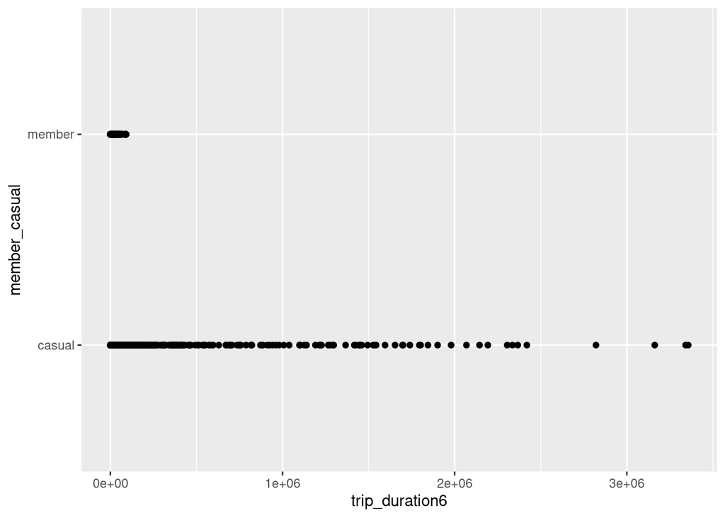

```r
ggplot(data = Jun_filtered, aes(x = trip_duration6, y = member_casual)) +
    geom_point()
```

#### Max Trip and Min Trip

Before filtering, the shortest trip by members was -306 seconds. Following is 1 trip of -1 seconds, and 19 trips of 0 seconds. For casual riders, the shortest trip was -192 seconds. Nest are two trips of -1 seconds. Then 44 trips of 0 seconds.

The longest trip for members was 89997 seconds. The longest trip for casual riders is 3356649 seconds.

```r
Jun_c_trip_max <- (max(Jun_casual$trip_duration6))
Jun_m_trip_max <- (max(Jun_members$trip_duration6))
Jun_c_trip_min <- (min(Jun_casual$trip_duration6))
Jun_m_trip_min <- (min(Jun_members$trip_duration6))
```

#### Bike Type

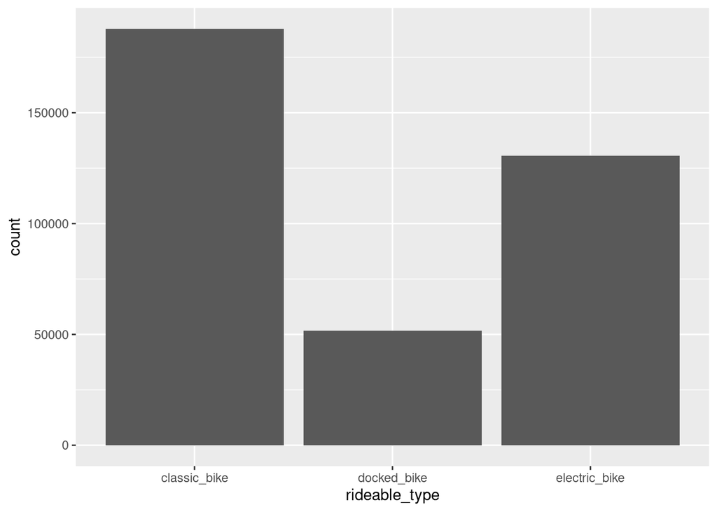

```r
Jun_c_elec <- length(which(Jun_casual$rideable_type == "electric_bike"))
Jun_c_classic <- length(which(Jun_casual$rideable_type == "classic_bike"))
Jun_c_docked <- length(which(Jun_casual$rideable_type == "docked_bike"))
ggplot(data = Jun_casual, aes(x = rideable_type)) +
     geom_bar()
```

Casual members took 187939 trips on classic bikes, 130526 trips on electric bikes, and 51667 trips on docked bikes.

[figure not shown]

```r
Jun_m_elec <- length(which(Jun_members$rideable_type == "electric_bike"))
Jun_m_classic <- length(which(Jun_members$rideable_type == "classic_bike"))
Jun_m_docked <- length(which(Jun_members$rideable_type == "docked_bike"))
ggplot(data = Jun_casual, aes(x = rideable_type)) +
     geom_bar()
```

Annual members took 246086 trips on classic bikes, 111946 trips on electric bikes, and none on docked bikes. .